# IS LM BP under Fixed and Floating Exchange Rate Regimes

Nicole Fleskes

November 15, 2018

## IS LM BP under Fixed and Floating Exchange rate Regimes

### Fixed

#### First, we define our variables:

```r
a_0 <- 80 # autonomous consumption
a_1 <- 0.8 # marginal propensity to consume
i_0 <- 25 # autonomous private investment
i_1 <- -5 # marginal propensity to invest
g_0 <- 40 # government expenditure
x_0 <- 25 # autonomous level of exports
m_0 <- 20 # autonomous level of imports
m_1 <- 0.15 # marginal propensity to import
t_rate <- 0.15 # Tax rate
c_1 <- (a_0+i_0+g_0+x_0-m_0) # autonomous values
c_2 <- (1-a_1*(1-t_rate)+m_1) # marginal values
l_1 <- 0.5 # liquidity function for motive 1
l_2 <- -5 # liquidity function for motive 2
k_prm <- 6 # increase in financial account (function of the interest rate)
```

#### Then we calculate the interest rate, equilibrium y, and money supply:

```r
int_rate_calc <- (((x_0-m_0)/m_1)-(c_1/c_2))/((i_1/c_2)-(k_prm/m_1))
y_calc <- ((x_0-m_0)/m_1)+(k_prm*int_rate_calc/m_1)
m_no_bar <- l_1*y_calc+l_2*int_rate_calc
```

```
## [1] "Interest rate:"
```

```
## [1] 5.644258
```

```
## [1] "Output:"
```

```
## [1] 259.1036
```

```
## [1] "Money Supply:"
```

```
## [1] 101.3305
```

#### Create a dataframe with 1000 rows called IS_LM_BP with a column of observation numbers.

```r
obs <- c(seq(1,1000,by=1))
IS_LM_BP <- data.frame(obs)
head(IS_LM_BP)
```

```
##   obs
## 1   1
## 2   2
## 3   3
## 4   4
## 5   5
## 6   6
```

#### Perform our dataframe operations to fill it with the values for the curves.

```r
#Generate Data
IS_LM_BP["int_rate_s"] <- IS_LM_BP["obs"]/100
IS_LM_BP["Y_IS"] <- (c_1/c_2)+(i_1*IS_LM_BP["int_rate_s"]/c_2)
IS_LM_BP["Y_LM"] <- (m_no_bar/l_1)-(l_2*IS_LM_BP["int_rate_s"]/l_1)
IS_LM_BP["Y_BP"] <- ((x_0-m_0)/m_1)+(k_prm*IS_LM_BP["int_rate_s"]/m_1)

#Drop obs cols
IS_LM_BP <- IS_LM_BP[-c(1)]
head(IS_LM_BP)
```

```
##   int_rate_s     Y_IS     Y_LM     Y_BP
## 1       0.01 319.0426 202.7611 33.73333
## 2       0.02 318.9362 202.8611 34.13333
## 3       0.03 318.8298 202.9611 34.53333
## 4       0.04 318.7234 203.0611 34.93333
## 5       0.05 318.6170 203.1611 35.33333
## 6       0.06 318.5106 203.2611 35.73333
```

#### Calculate the IS, LM, and BP curve equilibrium values. All of the output values should be the same!

```r
y_is = (c_1/c_2)+(i_1*int_rate_calc/c_2)
y_lm = (m_no_bar/l_1)-(l_2*int_rate_calc/l_1)
y_bp = ((x_0-m_0)/m_1)+(k_prm*int_rate_calc/m_1)
```

```
## [1] "Equilibrium level of output from the IS curve:"
```

```
## [1] 259.1036
```

```
## [1] "Equilibrium level of output from the LM curve"
```

```
## [1] 259.1036
```

```
## [1] "Equilibrium level of output from the BP curve"
```

```
## [1] 259.1036
```

#### Melt the dataframe into long format

First, however, we have to melt the data frame into a long form.

Wide format: Each observation has it’s own row. In this case, each interest rate and it’s corresponding values for IS, LM, and BP are contained in a column in the same row.

Long Format: Each unit of analysis is separated into it’s own row. In this case, each interest rate is going to have have a row for each IS, LM, and BP value.

We “melt” the data frame to change the formats to allow us to graph it.

```r
#Before reshape
head(IS_LM_BP)
```

```
##   int_rate_s     Y_IS     Y_LM     Y_BP
## 1       0.01 319.0426 202.7611 33.73333
## 2       0.02 318.9362 202.8611 34.13333
## 3       0.03 318.8298 202.9611 34.53333
## 4       0.04 318.7234 203.0611 34.93333
## 5       0.05 318.6170 203.1611 35.33333
## 6       0.06 318.5106 203.2611 35.73333
```

```r
#reshapea and rename df
df <- melt(IS_LM_BP, id="int_rate_s")

#after reshape
head(df,10)
```

```
##    int_rate_s variable    value
## 1        0.01     Y_IS 319.0426
## 2        0.02     Y_IS 318.9362
## 3        0.03     Y_IS 318.8298
## 4        0.04     Y_IS 318.7234
## 5        0.05     Y_IS 318.6170
## 6        0.06     Y_IS 318.5106
## 7        0.07     Y_IS 318.4043
## 8        0.08     Y_IS 318.2979
## 9        0.09     Y_IS 318.1915
## 10       0.10     Y_IS 318.0851
```

As you can see above, the reshaped dataframe only has columns for the interest rate, the variable label, and the variable value.

Why do we do this? In order to graph multiple lines on one plot, we need one set of x and y values. Melting the dataframe into long format allows us to plot all the data on one graph easily.

x values to plot: intrest rate y values to plot: IS, LM, BP (color coded)

#### Plot the curves using ggplot2

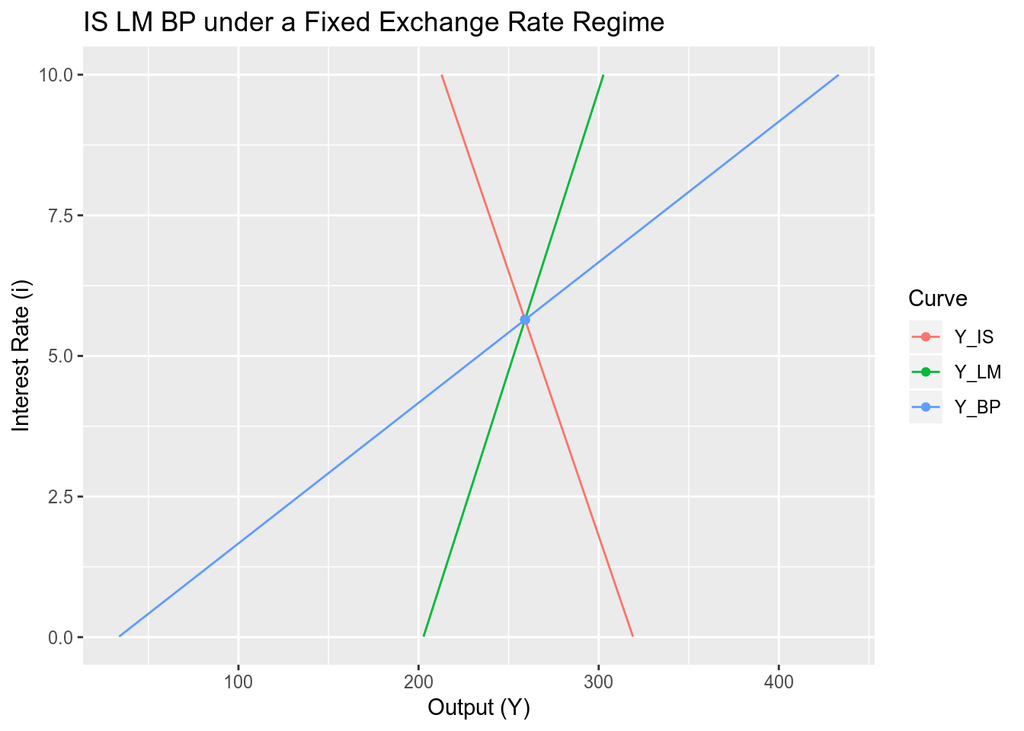

```r
#plot IS LM BP
ggplot(data=df, aes(x=value,y=int_rate_s, color=variable))+
  geom_line() +
  geom_point(x=y_is,y=int_rate_calc) +
  labs(title="IS LM BP under a Fixed Exchange Rate Regime",x="Output (Y)",y="Interest Rate (i)",colour="Curve")
```

### Floating

#### First, we define our variables. However we only need a few additional ones:

```r
a_0 <- 80 # autonomous consumption
a_1 <- 0.8 # marginal propensity to consume
i_0 <- 25 # autonomous private investment
i_1 <- -5 # marginal propensity to invest
g_0 <- 40 # government expenditure
x_0 <- 25 # autonomous level of exports
m_0 <- 20 # autonomous level of imports
m_1 <- 0.15 # marginal propensity to import
t_rate <- 0.15 # Tax rate
c_1 <- (a_0+i_0+g_0+x_0-m_0) # autonomous values
c_2 <- (1-a_1*(1-t_rate)+m_1) # marginal values
l_1 <- 0.5 # liquidity function for motive 1
l_2 <- -5 # liquidity function for motive 2
k_prm <- 6 # increase in financail account (function of the interest rate)

# Additional Variables Required
x_1 <- 0.4 # marginal propensity to export
m_2 <- 0.15 # marginal propensity to import
m_bar <- 115  # money supply
c_3 <- (l_2*(m_2-c_2)-l_1*(i_1-k_prm)) #marginal values using exports and imports
```

#### Then we calculate the interest rate, equilibrium y, and exchange rate adjusted for a floating exchange rate regime:

```r
int_rate_calc <-(m_bar*(m_2-c_2)-l_1*((x_0-m_0)-c_1))/c_3
y_calc <- (m_bar/l_1)-(l_2*int_rate_calc/l_1)
xr_calc <- (c_2*y_calc-c_1-i_1*int_rate_calc)/(x_1-m_1)
```

```
## [1] "Interest rate:"
```

```
## [1] 5.028169
```

```
## [1] "Output:"
```

```
## [1] 280.2817
```

```
## [1] "Exchange Rate:"
```

```
## [1] 27.49296
```

#### Create a dataframe with 1000 rows called IS_LM_BP with a column of observation numbers.

```r
obs <- c(seq(1,1000,by=1))
IS_LM_BP <- data.frame(obs)
head(IS_LM_BP)
```

```
##   obs
## 1   1
## 2   2
## 3   3
## 4   4
## 5   5
## 6   6
```

#### Perform our dataframe operations to fill it with the values for the curves.

```r
#Generate Data
IS_LM_BP["int_rate_s"] <- IS_LM_BP["obs"]/100
IS_LM_BP["Y_IS"] <- (c_1+xr_calc*(x_1-m_1)+i_1*IS_LM_BP["int_rate_s"])/c_2
IS_LM_BP["Y_LM"] <- (m_bar/l_1)-(l_2*IS_LM_BP["int_rate_s"]/l_1)
IS_LM_BP["Y_BP"] <- ((x_0-m_0)+xr_calc*(x_1-m_1)+k_prm*IS_LM_BP["int_rate_s"])/m_2

#Drop obs cols
IS_LM_BP <- IS_LM_BP[-c(1)]
head(IS_LM_BP)
```

```
##   int_rate_s     Y_IS  Y_LM     Y_BP
## 1       0.01 333.6665 230.1 79.55493
## 2       0.02 333.5601 230.2 79.95493
## 3       0.03 333.4537 230.3 80.35493
## 4       0.04 333.3473 230.4 80.75493
## 5       0.05 333.2409 230.5 81.15493
## 6       0.06 333.1346 230.6 81.55493
```

#### Calculate the IS, LM, and BP curve equilibrium values. All of the output values should be the same!

```r
y_is = (c_1+xr_calc*(x_1-m_1)+i_1*int_rate_calc)/c_2
y_lm = (m_bar/l_1)-(l_2*int_rate_calc/l_1)
y_bp = ((x_0-m_0)+xr_calc*(x_1-m_1)+k_prm*int_rate_calc)/m_2
```

```
## [1] "Equilibrium level of output from the IS curve:"
```

```
## [1] 280.2817
```

```
## [1] "Equilibrium level of output from the LM curve"
```

```
## [1] 280.2817
```

```
## [1] "Equilibrium level of output from the BP curve"
```

```
## [1] 280.2817
```

#### Melt the dataframe into long format

```r
#reshapea and rename df
df <- melt(IS_LM_BP, id="int_rate_s")
```

#### Plot the curves using ggplot2

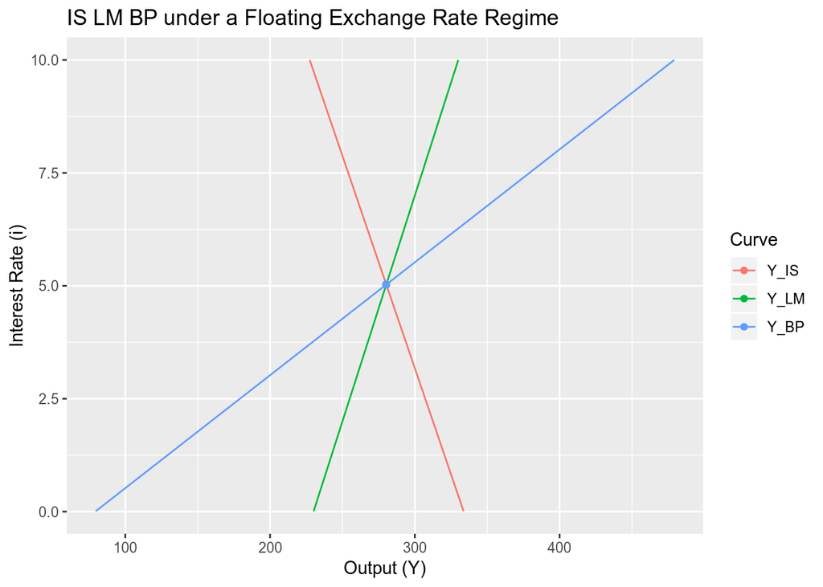

```r
#plot IS LM BP
ggplot(data=df, aes(x=value,y=int_rate_s, color=variable))+
  geom_line() +
  geom_point(x=y_is,y=int_rate_calc) +
  labs(title="IS LM BP under a Floating Exchange Rate Regime",x="Output (Y)",y="Interest Rate (i)",colour="Curve")
```